# R & Proteomics

## 9.3 WGCNA

### 9.3.1 Run

There’s a lot of variables you can and some you should not play with without knowing what your doing.

following you can play with: - power –> set higher lower, based on how it looks in the heatmap (downstream) - minModuleSize –> depeding on the number of proteins you got you might in or decrease this. Roughly 5 to 25 modules is nice to have. More or less and it becomes a bit difficult. - corType –> ‘pearson’ or ‘bicor’. For proteomics I like bicor more. - maxPOutliers –> Only play around with when selecting bicor for cortype. 0.1 worked well often, but again; one can play with it. - verbose –> integer level of verbosity. Zero means silent, higher values make the output progressively more and more verbose. - deepSplit –> nteger value between 0 and 4. Provides a simplified control over how sensitive module detection should be to module splitting, with 0 least and 4 most sensitive.

```r
#Run the WGCNA
WGCNA_results <- blockwiseModules(
  datExpr = WGCNA_data_prepare,
  networkType = "signed",
  power = 20,
  minModuleSize = 20,
  corType = "bicor",
  maxPOutliers = 0.1,
  verbose = 3,
  deepSplit = 4,

  #Standard settings below.
  reassignThreshold = 1e-6,
  mergeCutHeight = 0.15,
  minKMEtoStay = 0.3,
  minCoreKME = 0.5,
  TOMType = "unsigned",
  numericLabels = T,
  pamRespectsDendro = F

)
```

```
##  Calculating module eigengenes block-wise from all genes
##    Flagging genes and samples with too many missing values...
##     ..step 1
##  ..Working on block 1 .
##     TOM calculation: adjacency..
##     ..will not use multithreading.
##      Fraction of slow calculations: 0.810740
##     ..connectivity..
##     ..matrix multiplication (system BLAS)..
##     ..normalization..
##     ..done.
##  ....clustering..
##  ....detecting modules..
##  ....calculating module eigengenes..
##  ....checking kME in modules..
##      ..removing 1 genes from module 1 because their KME is too low.
##      ..removing 1 genes from module 3 because their KME is too low.
##      ..removing 1 genes from module 5 because their KME is too low.
##   ..reassigning 1 genes from module 3 to modules with higher KME.
##  ..merging modules that are too close..
##      mergeCloseModules: Merging modules whose distance is less than 0.15
##        Calculating new MEs...
```

### 9.3.2 Extract colours + Dendrogram

The WGCNA is now created. Lets grab the results and plot it in a Heatmap.

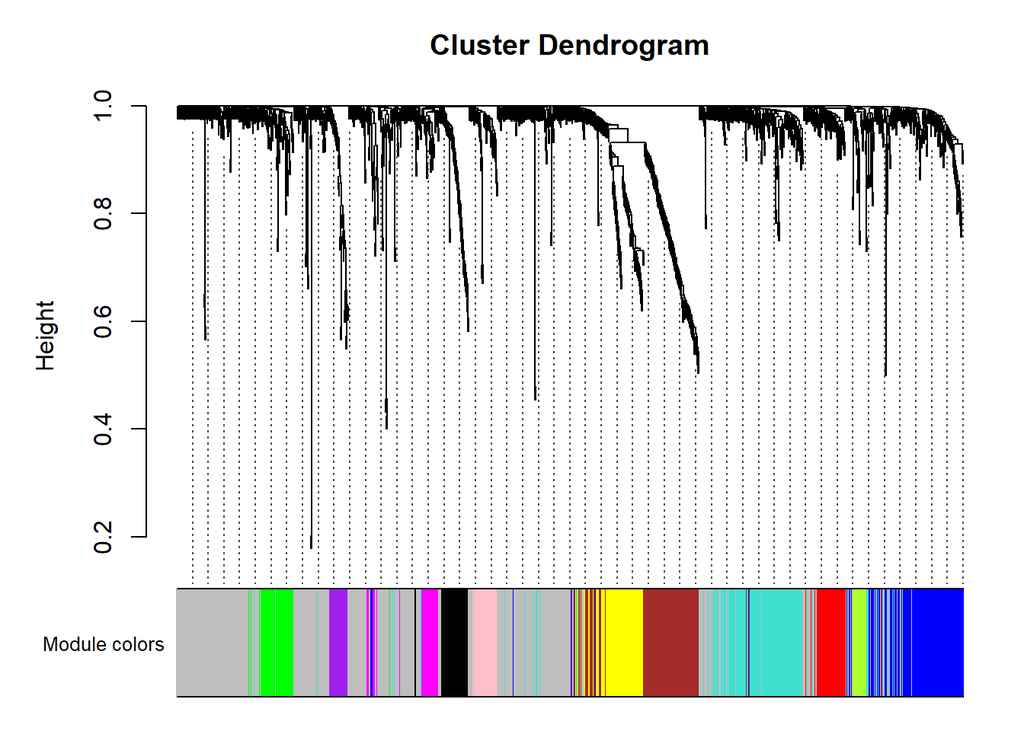

```r
#Get module colours
mergedcolors <- labels2colors(WGCNA_results$colors)
module_labels = paste0("mod",WGCNA_results$colors) %>% setNames(names(WGCNA_results$colors))
module_color_key = labels2colors(unique(WGCNA_results$colors)) %>% setNames(paste0("mod",unique(WGCNA_results$colors)))

#Plot the colour dendorgram
    # Plot the dendrogram and the module colors underneath
    plotDendroAndColors(
      WGCNA_results$dendrograms[[1]],
      mergedcolors[WGCNA_results$blockGenes[[1]]],
      "Module colors",
      dendroLabels = FALSE,
      hang = 0.03,
      addGuide = TRUE,
      guideHang = 0.05
    )
```

### 9.3.3 Heatmap

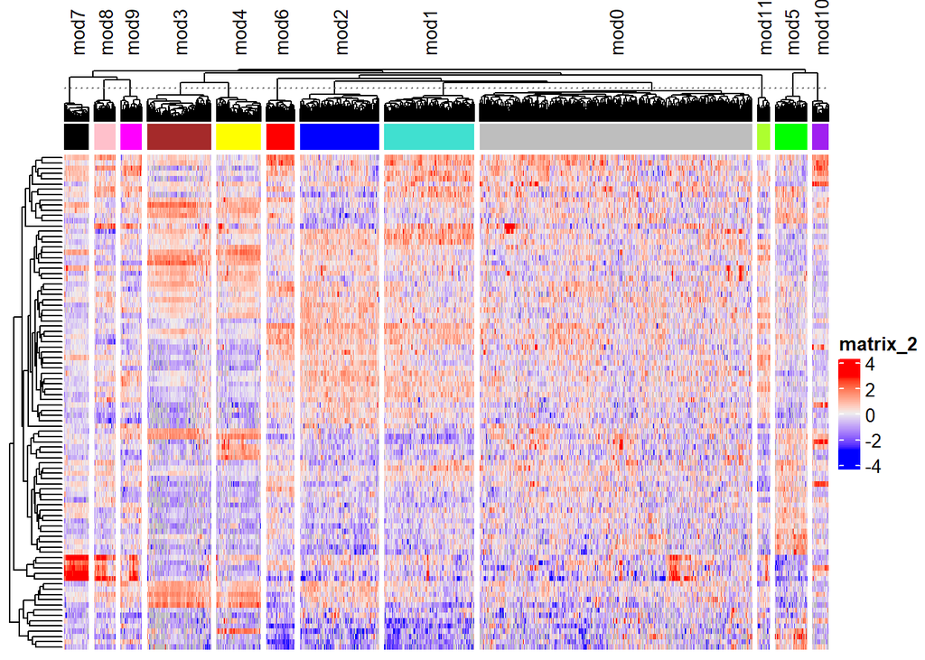

```r
#Define for each of the proteins which modules it is part of.  NOTE, module 0 means it wasnt added to any.
module_membership = data.frame( feature = colnames(WGCNA_data_prepare), module = module_labels )
module_for_plot = module_membership$module #Need this one for the plot below.

#change the WGCNA input data to a matrix
#This is needed for the ComplexHeatmap.... Its confusing!
WGCNA_data_prepare_matrix <- as.matrix(scale(WGCNA_data_prepare)) #Do note the scale! This is column-wise Z-scoring

#Create the Heatmap
Heatmap(
  WGCNA_data_prepare_matrix, #Data that we Z-scored and put in matrix format above.
  column_split = module_membership$module, #The modules
  top_annotation = columnAnnotation(
    modules = module_for_plot,
    col=list(modules = module_color_key),
    show_legend = FALSE,
    show_annotation_name = FALSE),
  show_column_names = F,
  show_row_names = F,
  column_title_rot = 90,
  column_title_gp = gpar(fontsize=10)
)
```

### Heatmap - With Clinical

If you’re happy with your WGCNA clustering, or you want to add the clinical info anyway here’s the way to do it. We need to make an additional little dataframe with our clinical factors.

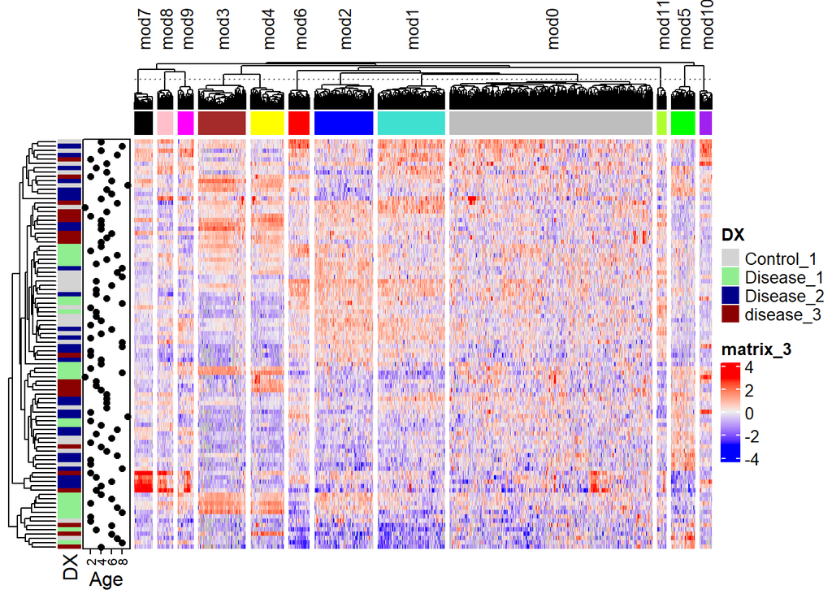

```r
WGCNA_clinicalInfo <- clinical_and_protein_joined_70prct %>%
  spread(key = Protein, value = Intensity) %>% #spread like we do before
  dplyr::select(SampleID, DX, Fake_Age)  #Select only columns of interest

#Repeat the plotting as above, but with left_annotation
#Create the Heatmap
Heatmap(
  WGCNA_data_prepare_matrix, #Data that we Z-scored and put in matrix format above.
  column_split = module_membership$module, #The modules
  top_annotation = columnAnnotation(
  modules = module_for_plot,
  col=list(modules = module_color_key),
  show_legend = FALSE,
  show_annotation_name = FALSE),
  show_column_names = F,
  show_row_names = F,
  column_title_rot = 90,
  column_title_gp = gpar(fontsize=10),

  #Define clinical annotations
  left_annotation = rowAnnotation(
    DX = WGCNA_clinicalInfo$DX,
    Age = anno_points(WGCNA_clinicalInfo$Fake_Age), #anno points makes the (I think) nice dots. See Complexheatmap website for more ideas.
    col = list(
      DX = c("Control_1" = "lightgrey",
             "Disease_1" = "lightgreen",
             "Disease_2" = "darkblue",
             "disease_3" = "darkred"))
    )
)
```

## 9.4 Modules - Statistics

Instead of doing a t-test or ANOVA on single genes, we can also do it on the modules. To do so, we need to do the following:

- extract module quant info (called eigengenes)
- Connect this to our clinical data
- Run our statistics
- Visualization

### 9.4.1 Extract module-quant from the WGCNA

The WGCNA package has a function to extract this info. We just use that.

```r
# Recalculate module eigengenes with module labels
moduleQuants <- moduleEigengenes(
  WGCNA_data_prepare, #ORIGINAL DF OF WGCNA!
  module_labels
  )

#Inside now there's multiple dataframes, such as eigengenes, averagexpression or variance. Here we take eigengenes and re-write it
moduleQuants <- moduleQuants$eigengenes
```

#### 9.4.1.1 Connect to Clinical

```r
# We do three steps to prepare for joining with the clinical data
# 1. Re-create the clinical sampleID column
# 2. Make into long format
# 3. make the clinical sampleID column numeric
moduleQuants <- moduleQuants %>%

  #Re-get the rownames.
  rownames_to_column(var = "SampleID") %>%

  # Make it into long format. I specify colnames because at this point we have not overwritten it yet, thus we can take that.
  gather(colnames(moduleQuants), key = "module", value = "eigengenes") %>%

  #In our clinical dataframes the SampleID is describes as numeric, not character. Thus we need to change that.
  #This again really depends on your own clinical data. It can be tricky and need a bit of trial and error..
  mutate(SampleID = as.numeric(SampleID))

#Combine with the clinical data
moduleQuants_clinical <- inner_join(
  clinical_only,
  moduleQuants,
  by = c("SampleID" = "SampleID")
)
```

### 9.4.2 Module - Anova

We run the anova_test similair to how we done in chapter 4.

```r
#Run ANOVA
moduleQuants_anova <- moduleQuants_clinical %>%
  group_by(module) %>%
  anova_test(eigengenes ~ DX, detailed = T) %>%

  #Apply BH correction
  ungroup() %>%
  adjust_pvalue(method = "BH")
```

### 9.4.3 Visualize - boxplot

Looking at the anova results data we notice that modules 1 and 4 are significant. Lets make boxplots and also apply that pairwise test we’ve done before in chapter 4.

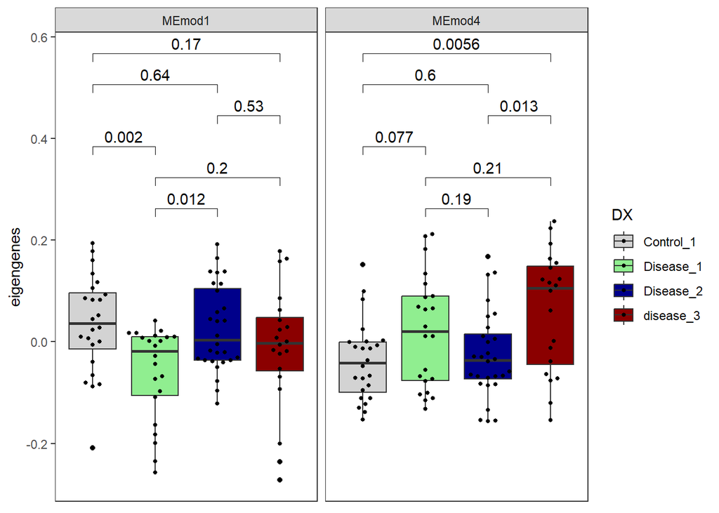

```r
#We need to specify which comparisons we want post-hoc to do.
my_comparisons <- list(
  c("Disease_1", "Disease_2"),
  c("Disease_1", "disease_3"),
  c("Disease_1", "Control_1"),
  c("Disease_2", "disease_3"),
  c("Disease_2", "Control_1"),
  c("disease_3", "Control_1")
  )


moduleQuants_clinical %>%
  filter(module %in% c("MEmod1", "MEmod4")) %>%

  #plot
  ggplot(aes(x = DX, y = eigengenes, fill = DX)) +
  geom_boxplot() +
  geom_beeswarm(cex = 3, size = 1, color = "black") +
  stat_compare_means(comparisons = my_comparisons) +
  scale_fill_manual(values = c("lightgrey", "lightgreen", "darkblue", "darkred")) +
  xlab("") +
  ylab("eigengenes") +
  facet_wrap(~module) +
  theme_bw() +
  theme(
    axis.title.x=element_blank(),
    axis.text.x=element_blank(),
    axis.ticks.x=element_blank(),
    panel.grid.major = element_blank(),
    panel.grid.minor = element_blank())
```

## 9.5 Enrichment of Modules

Of course it is also interesting to enrich for the specific modules. Here I apply the hallmark-enrichment as we did in the enrichment chapter.

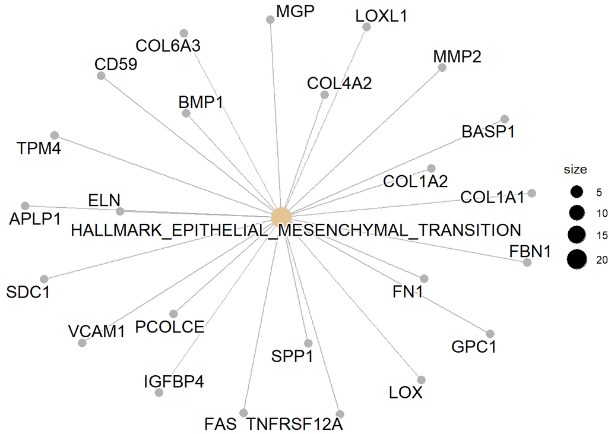

```r
#Set the msgidb. We specify HALLMARK, but you can select any (or all by not specifying any) from the weblink above
all_gene_sets = msigdbr(species = "Homo sapiens", category = "H")
msigdbr_t2g = all_gene_sets %>%
  dplyr::distinct(gs_name, gene_symbol) %>%
  #mutate(gs_name = str_remove_all(gs_name, "HALLMARK_")) %>% #REMOVE ALL THE HALLMARK STUFF
  as.data.frame()

# Specify the background (i.e. all proteins) if you want
hallmark_background <- module_membership %>%
  separate(feature, sep = "_", into = c("Uniprot", "Gene"))

#Filter module 1
hallmark_module1 <- hallmark_background %>%
  filter(module == "mod1")

#Run Enrichment
WGCNA_hallmark_enrich_mod1 <- enricher(
  gene = hallmark_module1$Gene,
  universe = hallmark_background$Gene,
  TERM2GENE = msigdbr_t2g
)

#View Results
#View(hallmark_enrichments@result)

#We can again use some of the Clusteprofiler tools to visualize
cnetplot(
  WGCNA_hallmark_enrich_mod1
         )
```

# 10 Peptide All-in-One and Plots

Sometimes we want to do peptide-level analyses. There’s a lot of statistics one can do, here I created a function that can do all automaticly (it will take a whole though). It is important to know that we do need the FASTA file, because we want to identify for each peptide the protein length and at which location the peptide originates from.

## 10.1 Imports

```r
#Import the peptide level data
peptide_level_data <- read_csv("Cleaned_diaNN_peptideMatrix.csv")

#This dataframes has a lot of unique proteins in it. The statistics will take long.
# Thus, I selected 5 proteins that had a nice number of peptides to its name. Just for showing purposes.
peptide_level_data_50proteins <- peptide_level_data %>%
  separate(Protein, sep = "_", into = c("Uniprot", "Gene", "Peptide"), remove = F) %>%
  filter(Gene %in% c("TMSB4X", "APOH", "VASP", "CFI", "NACA")) %>%
  dplyr::select(- Uniprot, - Gene, - Peptide)

#FASTA FILE
myFastaFile <- seqinr::read.fasta(
  file = "UP000005640_9606_SARS_COV_2_BJOERN.fasta",
  seqtype = "AA",
  as.string = T)

#Clinical data
clinical_data <- read_csv("Clinical.csv")
clinical_data <- clinical_data %>%
  mutate(SampleID = as.character(SampleID))
```

## 10.2 Combine peptide and clinical data

See chapter 3 for more details.

```r
#Prepare the sample ID names
peptide_level_data_50proteins <- peptide_level_data_50proteins %>%
  separate(Sample, sep = "_", into = c("Acquistion", "sampleNumber", "PlateInfo", "timsTOF_stuff", "runOrder")) %>%
  dplyr::select(Protein, sampleNumber, Intensity)

#Join the two.
clinical_and_peptides <- inner_join(
  clinical_data,
  peptide_level_data_50proteins,
  by = c("SampleID" = "sampleNumber")
)
```

## 10.3 Multiple-statistical-tests-in-one

### 10.3.1 Function

This one is long, as we do many statistical tests in one and join the dataframes together. The comments below should explain each step.

```r
all_in_one <- function(dataset, sampleName, grouping, protOrPepName, intensityName, addOriginal = TRUE) {

#do some column renaming so we are sure it will work downstream within this function
  dataset <- dataset %>%
    mutate(sampleName = get(sampleName),
           grouping = get(grouping),
           protOrPepName = get(protOrPepName),
           intensityName = get(intensityName)) %>%
    dplyr::select(sampleName, grouping, protOrPepName, intensityName)

    print("Start Fisher Tests")

  #Fisher Tests
  dataset_counts <-
    dataset %>%
    dplyr::select(sampleName, grouping, protOrPepName, intensityName) %>%
    group_by(protOrPepName, grouping) %>%

    #Count the number of quantified proteins (and vice-verca, missing)
    summarise(Quantified = sum(!is.na(intensityName)),
              Missing = sum(is.na(intensityName))) %>%
    ungroup() %>%

    #run fisher test for each of the prot/peptides
    group_by(protOrPepName) %>%
    mutate(p_fisher = fisher.test(matrix(c(Quantified, Missing), nrow =2))$p) %>%

    #Make some of the columns into wide format as this will be nicer to join and write to csv downstream.
    pivot_wider(names_from = grouping,
                values_from = c(Quantified, Missing)) %>%
    relocate(p_fisher, .after = last_col()) %>%

    #Run p.adjustment
    ungroup() %>%
    mutate(padj_fisher = p.adjust(p_fisher, method = "BH"))

  print("Fisher Done")

  #Determine which proteins have at least two quants in the groups
  #We use this for both statistical tests as well as AUROC's
  dataset_possible <- dataset %>%
    dplyr::select(sampleName, grouping, protOrPepName, intensityName) %>%

    #check if value is NA
    mutate(isAValue = ifelse(is.na(intensityName), 0, 1)) %>%
    group_by(protOrPepName, grouping) %>%

    #count NA's per protein per group
    summarise(count = sum(isAValue)) %>%
    ungroup() %>%
    group_by(protOrPepName) %>%

    #if any of the groups for a given protein has less than two quants, write FALSE
    #The false column is used to filter proteins out we do not want to do any statistics on.
    mutate(dropColumn = ifelse(any(count < 2), F, T)) %>%
    ungroup() %>%
    filter(dropColumn)



  #Create list of all possible pairwise combinations of the clinical groups provided
  aurocPossibleCombinations <- apply(combn(unique(dataset$grouping),2),2,paste,collapse='-')

  #Based on that list, we keep duplicating the dataframe to include all potential combinations as unique numbers.
  AurocDF <- data.frame(matrix(ncol = ncol(dataset), nrow = 0))
  colnames(AurocDF) <- colnames(dataset)
  for (possibleComparison in aurocPossibleCombinations){
    dataset_temp <- dataset %>%
      mutate(comparison = possibleComparison)
    AurocDF <- rbind(AurocDF, dataset_temp)

  }

  #AUROC function
  Auroc_results <- AurocDF %>%

    #filter for the ones with at least two quants
    filter(protOrPepName %in% dataset_possible$protOrPepName) %>%

    #Here we split the comparison column we created above.
    #next, we check whether our grouping variable correpsonds to one of the two comparison variables
    #if yes, give it a binary (i.e. 0 or 1)
    #Next, we put the binary columns into one long one, followed by removing NA's
    separate(comparison, sep = "-", into = c("first", "second"), remove = F) %>%
    mutate(binaryStatusFirst = ifelse(grouping == first, 1, NA),
           binaryStatusSecond = ifelse(grouping == second, 0, NA)) %>%
    gather(c(binaryStatusFirst, binaryStatusSecond), key = "test", value = "binaryStatus") %>%
    drop_na(binaryStatus) %>%

    #We want to do a single AUROC for a combination of comparison and prot/peptide
    # we select the columns we need. Factorize the binarystatus column and run the ROC for the groupings
    #After, select columns of interest and spread them so they can be combined with the other analyses later on.
    dplyr::select(comparison, protOrPepName, binaryStatus, intensityName) %>%
    mutate(binaryStatus = as.factor(binaryStatus)) %>%
    group_by(comparison, protOrPepName) %>%
    roc_auc(truth = binaryStatus, intensityName) %>%
    dplyr::select(comparison, protOrPepName, .estimate) %>%
    ungroup() %>%
    mutate(comparison = paste0("AUROC_", comparison)) %>%
    spread(comparison, .estimate)

  print("AUROC Done")

  # Run the ANOVA
  anova_results <- dataset %>%

    #filter for the ones with at least two quants
    filter(protOrPepName %in% dataset_possible$protOrPepName) %>%

    drop_na(intensityName) %>%
    group_by(protOrPepName) %>%
    anova_test(intensityName ~ grouping, detailed = T) %>%
    adjust_pvalue(method = "BH")

    #Somehow doing this stuff we cant do direct. Need to transform it to a dataframe...
    anova_results <- data.frame(anova_results) %>%
    mutate(p_ANOVA = p,
           padj_ANOVA = p.adj) %>%
    dplyr::select(protOrPepName, p_ANOVA, padj_ANOVA)

  pairwise_results <- AurocDF %>%

    #filter for the ones with at least two quants
    filter(protOrPepName %in% dataset_possible$protOrPepName) %>%

    #Run all T-tests.
    drop_na(intensityName) %>%
    group_by(protOrPepName) %>%
    t_test(intensityName ~ grouping, detailed = T) %>%


    #Create the comparisons, p-value, and FC columns
    mutate(
      comparison = paste0(group1, "_", group2),
      FC = estimate,
      pvalue = p
    ) %>%
    dplyr::select(protOrPepName, comparison, FC, pvalue) %>%

    #Ungroup and regroup based on comparison. We want to only to p-value adjust for these.
    ungroup() %>%
    group_by(comparison) %>%
    mutate(adj_pvalue = p.adjust(pvalue, method = "BH")) %>%

    #Widen the DF so it can fit with the other
    pivot_wider(
      names_from = comparison,
      values_from = c(FC, pvalue, adj_pvalue),
      names_glue = "{comparison}_{.value}" #Change how we put names together other way around
    )

  print("pairwise Results done!")

  #Now we can add the dataframes together! In some cases the original DF is very big, so we might not want to add it.
  #to do so, we have an additional variables in the function that we check.
  if (addOriginal == FALSE){

    #add all plus original together
  dataset_final <- dataset_counts %>%
    left_join(Auroc_results) %>%
    left_join(anova_results) %>%
    left_join(pairwise_results)

  } else {
    #add all without original together
    dataset_wide <- dataset %>%
      dplyr::select(protOrPepName, sampleName, intensityName) %>%
    spread(sampleName, intensityName)

  dataset_final <- dataset_counts %>%
    left_join(Auroc_results) %>%
    left_join(anova_results) %>%
    left_join(pairwise_results) %>%
    left_join(dataset_wide)


  }

  #Return the results data
  return(dataset_final)
}
```

### 10.3.2 Usage

See below how one would use the function. One only needs to specify the columns, that is all. It would work on both protein and peptide-level data too!!

```r
resultsDF <- all_in_one(dataset =  clinical_and_peptides,
                        sampleName = "SampleID",
                        grouping = "DX",
                        protOrPepName = "Protein",
                        intensityName = "Intensity",
                        addOriginal = TRUE)
```

```
## [1] "Start Fisher Tests"
## [1] "Fisher Done"
## [1] "AUROC Done"
## [1] "pairwise Results done!"
```

## 10.4 Add FASTA info - peptidelevel

With the resultsDF we now have a lot of statistical info, but if we want to visualize this over the protein sequence, we need FASTA info too. This is added separate.

### 10.4.1 Functions

```r
#The function itself. we need info on the FASTA variable. the input dataset and which one is the peptide and Uniprot column
addFASTAinfo <- function(FASTA, dataset, column_peptide, column_uniprot){

  #Fix FASTA stuff.
  myFastaFile_Annot <- getAnnot(object = FASTA)

  #Function to extract the proteinsequence, will be used in the functionm below
  proteinStringFunction <- function(UniprotID, StrippedPeptide) {

    #Define the results if they can not be found
    proteinSeq <- "noProteinSequence"
    proteinSeq_nchar <- 9999999
    peptideLength <- 9999999
    start_position <- 9999999
    AA_before <- "NoAABefore"
    AA_after <- "NoAAAfter"

    #Get the protein seq
    try(proteinSeq <- myFastaFile[grep(UniprotID, myFastaFile_Annot)][[1]][1])

    #determine protein and peptide length
    try(proteinSeq_nchar <- nchar(proteinSeq))
    try(peptideLength <- nchar(StrippedPeptide))

    #Get the start location of the peptide
    try(start_position <- str_locate(proteinSeq, StrippedPeptide)[1])

    #Get AA before and after
    try(AA_before <- substr(proteinSeq, (start_position -1), start_position -1))
    try(AA_after <- substr(proteinSeq, (start_position + peptideLength), (start_position + peptideLength)))

    #return all in one string, which we can use to transform back into columns later
    return(paste0(proteinSeq_nchar, "_", peptideLength, "_", start_position, "_", AA_before, "_", AA_after))
  }



  #making a cleanDF with peptide and Uniprot column
  dataset_clean <- dataset %>%

    #First, we make sure we have a peptide & Uniprot column, and that their naming is good. After, we select them.
    mutate(Peptide = get(column_peptide),
           Uniprot = get(column_uniprot)) %>%
    dplyr::select(Peptide, Uniprot)

  #Create the FASTA info
  FASTAINFO <- dataset_clean %>%

    #based on if it is MSFragger or DIA-NN, there can be some other items hidden we need to get rid of.
    mutate(strippedPeptide = gsub('[[:digit:]]+', '', Peptide)) %>%
    mutate(strippedPeptide = gsub("\\[|\\]", "", strippedPeptide)) %>%
    mutate(strippedPeptide = str_replace_all(strippedPeptide, ".UniMod..", "")) %>%
    mutate(strippedPeptide = gsub("\\.", "", strippedPeptide)) %>%


    #Use the function described above to get all FASTA related info
    mutate(allInfo = mapply(function(x,y) proteinStringFunction(x, y),
                                  Uniprot, strippedPeptide)) %>%
    separate(allInfo, sep = "_", into = c("proteinLength", "peptideLength", "startPosition", "AAbefore", "AAafter")) %>%
    mutate(proteinLength = as.numeric(proteinLength),
           startPosition = as.numeric(startPosition),
           peptideLength = as.numeric(peptideLength))

  #Join them together again. We do the @ thing to remove the duplicate names
  returnDF <- inner_join(FASTAINFO,
                         dataset,
                         suffix = c("", ".@"),
                         by = c("Peptide" = "Peptide")) %>%
    dplyr::select(-ends_with(".@"))

  return(returnDF)

}
```

### 10.4.2 Usage

To use we need to manually split the peptide-sequences from the other identifiers in the column. Here we have a UNIPROT_GENE_PEPTIDE type, so lets do that.

After that we specify the FASTA file, the dataset, and the peptide-column.

```r
#Do the split
resultsDF <- resultsDF %>%
  separate(protOrPepName, sep = "_", into = c("Uniprot", "Gene", "Peptide"))

#apply the function described above to get the DF as we want it.
resultsDF_withFASTAINFO <- addFASTAinfo(
    FASTA = myFastaFile,
    dataset = resultsDF,
    column_peptide = "Peptide",
    column_uniprot = "Uniprot"
  )
```

## 10.5 Plotting Peptide Results

### 10.5.1 Example

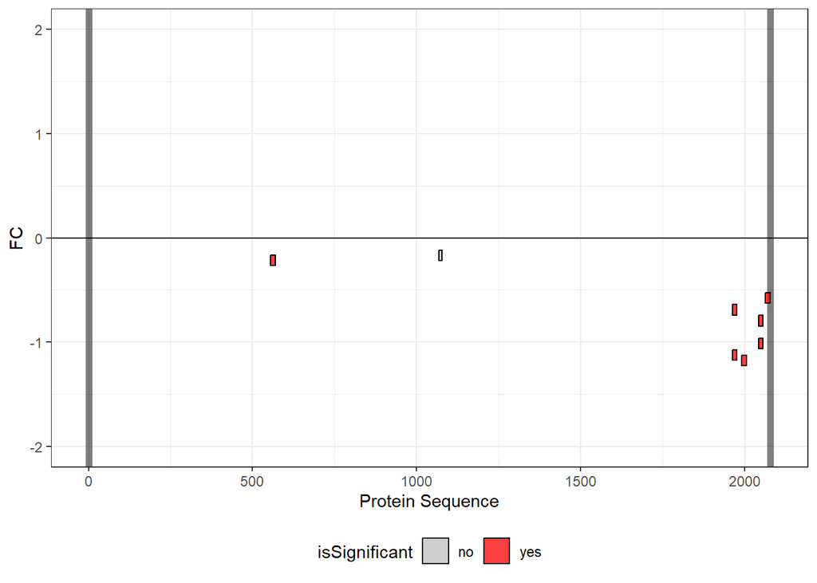

```r
#We need to select the protein we want first
proteinWeWantToPlot <- resultsDF_withFASTAINFO %>%
  filter(Uniprot == "E9PAV3")


#Now we can make the plot
proteinWeWantToPlot %>%

  #Lets make a column based on significance
  mutate(isSignificant = ifelse(Control_1_Disease_1_adj_pvalue < 0.05, "yes", "no")) %>%

  #Start plotting
  ggplot() +

  #We take here the 'mean' but this is of course X-times the same value
  #ylim(-2.5, 2.5)
  xlim(-10, mean(proteinWeWantToPlot$proteinLength)+10) +

  #Create some lines to help visualise the start and end of the protein.
  geom_vline(xintercept = 0, lwd = 2, alpha = .5) +
  geom_vline(xintercept = mean(proteinWeWantToPlot$proteinLength), lwd = 2, alpha = 0.5) +

  #set a horizontal line to inform about FC = 0
  geom_hline(yintercept = 0, color = "black") +

  #Here we build the peptide "blocks". Do note that all column-info goes INSIDE the aes() part.
  geom_rect(
      aes(
      xmin = startPosition,
      xmax = (startPosition + peptideLength),
      ymin = Control_1_Disease_1_FC-0.05,
      ymax = Control_1_Disease_1_FC+0.05,
      fill = isSignificant
      ),

    #Here I specify some stuff that will be universal for all blocks irrespective of column info.
    col = "black",
    alpha = 0.75) +

  #Set the Ggplot theme, limit the y-axis for FC.
  theme_bw() +
  ylim(-2, 2) +

  #Specify the colours I want to use for the isSignificant column
  scale_fill_manual(values = c("yes" = "red","no" = "grey")) +
  theme(legend.position = "bottom") +

  #x and yaxis titles
  xlab("Protein Sequence") +
  ylab("FC")
```

### Plot all

In some cases you just want plots of ALL proteins in your dataset. We can do this using a for-loop. If you do not know what a for-loop is, please had back to chapter 0 and re-learn some R…

In the for-loop we will go over each unique protein in the DF, make the plot and save it. that is all.

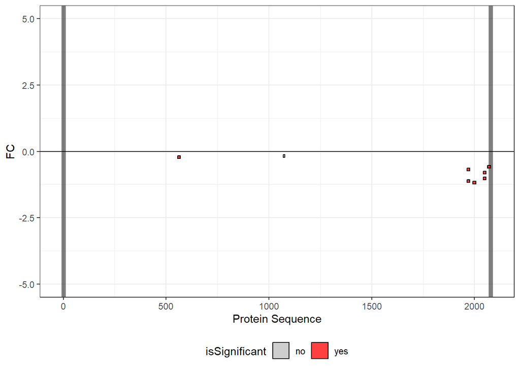

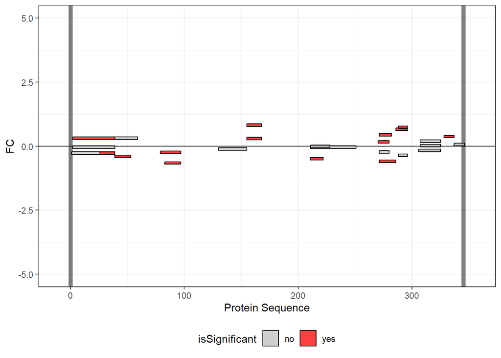

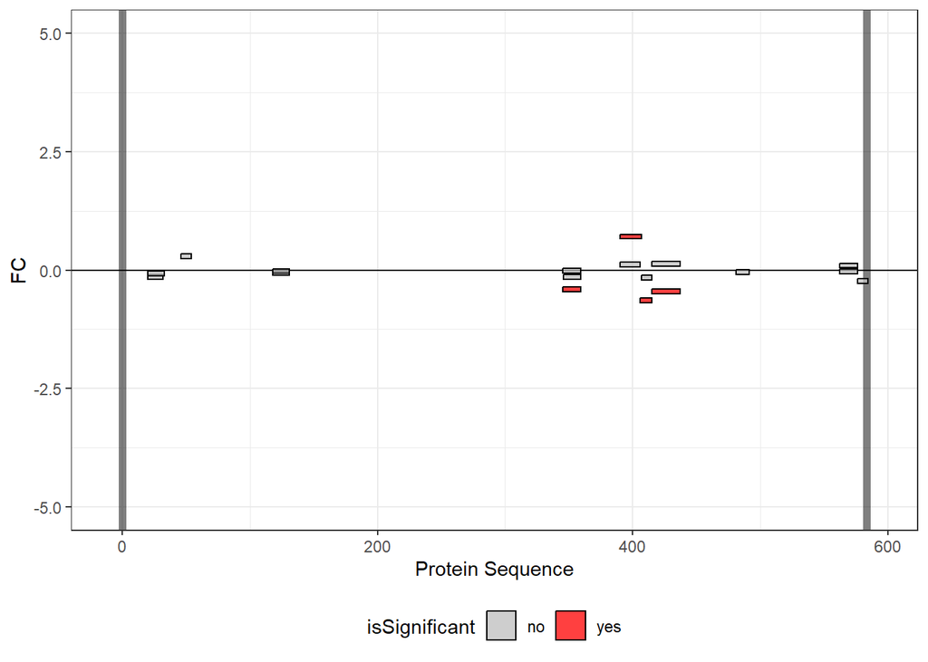

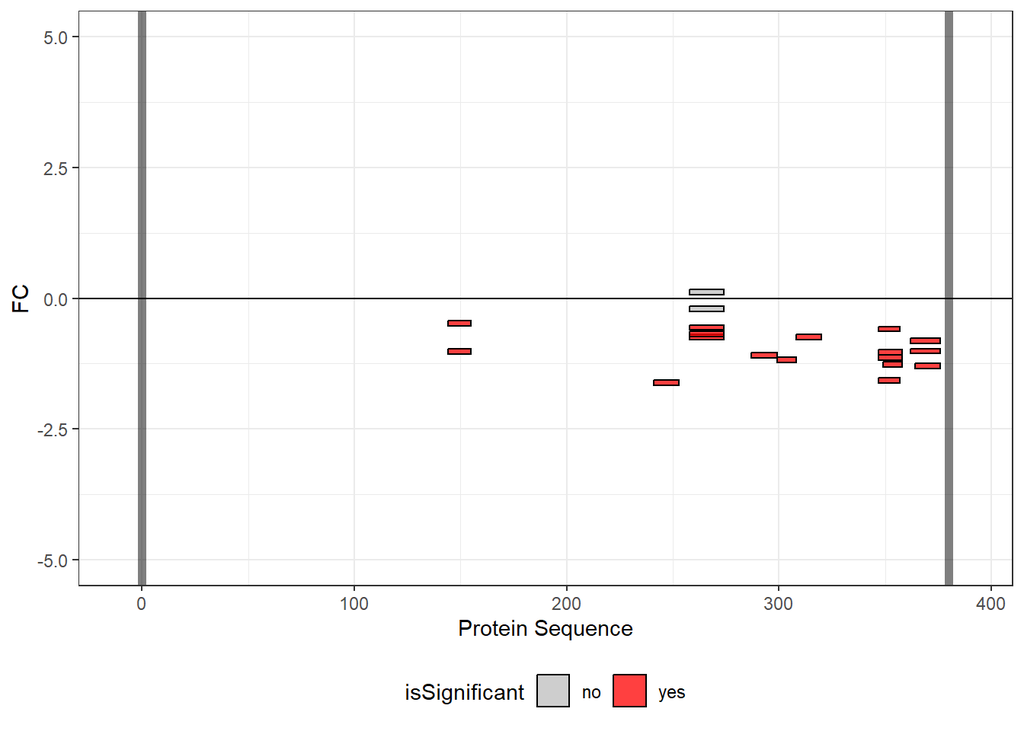

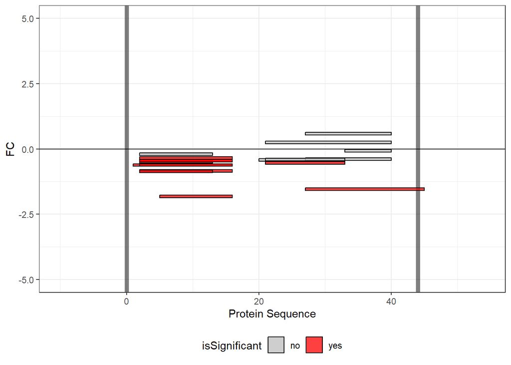

```r
#Create the for, using UNIQUE protein names
for (i in unique(resultsDF_withFASTAINFO$Gene)){


  #We need to select the protein we want first
  proteinWeWantToPlot <- resultsDF_withFASTAINFO %>%
    filter(Gene == i)


  #Now we can make the plot
  proteinPeptidePlot <- proteinWeWantToPlot %>%

    #Lets make a column based on significance
    mutate(isSignificant = ifelse(Control_1_Disease_1_adj_pvalue < 0.05, "yes", "no")) %>%

    #Start plotting
    ggplot() +

    #We take here the 'mean' but this is of course X-times the same value
    #ylim(-2.5, 2.5)
    xlim(-10, mean(proteinWeWantToPlot$proteinLength)+10) +

    #Create some lines to help visualise the start and end of the protein.
    geom_vline(xintercept = 0, lwd = 2, alpha = .5) +
    geom_vline(xintercept = mean(proteinWeWantToPlot$proteinLength), lwd = 2, alpha = 0.5) +

    #set a horizontal line to inform about FC = 0
    geom_hline(yintercept = 0, color = "black") +

    #Here we build the peptide "blocks". Do note that all column-info goes INSIDE the aes() part.
    geom_rect(
        aes(
        xmin = startPosition,
        xmax = (startPosition + peptideLength),
        ymin = Control_1_Disease_1_FC-0.05,
        ymax = Control_1_Disease_1_FC+0.05,
        fill = isSignificant
        ),

      #Here I specify some stuff that will be universal for all blocks irrespective of column info.
      col = "black",
      alpha = 0.75) +

    #Set the Ggplot theme, limit the y-axis for FC.
    theme_bw() +
    ylim(-5, 5) +

    #Specify the colours I want to use for the isSignificant column
    scale_fill_manual(values = c("yes" = "red","no" = "grey")) +
    theme(legend.position = "bottom") +

    #x and yaxis titles
    xlab("Protein Sequence") +
    ylab("FC")

  #Here we plot them in the Rmarkdown.
  plot(proteinPeptidePlot)

  #want to save them on the computer? Instead, run the part I commented here below.
  # i here defines the GeneName
  #ggsave(paste0("C:/Users/maste/Dropbox (BCH)/MyFolder1/Myfolder2/", i, ".png"))
}
```